# Estadística Descriptiva con Datos Cualitativos

Ramon Ceballos

26/1/2021

# EJEMPLO FINAL

Vamos a llevar a cabo un análisis completo de un ejemplo con lo que hemos aprendido en esta lección y aprovecharemos para aprender algo nuevo.

El objeto de datos **`HairEyeColor`** que lleva predefinido R es una tabla de frecuencias absolutas de tres variables cualitativas: color de cabello (`Hair`), color de los ojos (**`Eye`**) y sexo (**`Sex`**).

Vamos a extraer de esta tabla una *tabla bidimensional* de frecuencias absolutas de las variables **`Eye`** y **`Hair`**, sin distinguir según el sexo. La manera más sencilla de obtener esta tabla es sumando las subtablas de frecuencias para hombres y mujeres, y aplicando **`as.table()`** al resultado para transformarlo en una **`table`** por si no lo es.

**Chunk para obtener una tabla que considere Eye y Hair únicamente**

```r
#Se obtienen las frecuecnias relativas absolutas
ftable(HairEyeColor)
```

```
##             Sex Male Female
## Hair  Eye
## Black Brown       32     36
##       Blue        11      9
##       Hazel       10      5
##       Green        3      2
## Brown Brown       53     66
##       Blue        50     34
##       Hazel       25     29
##       Green       15     14
## Red   Brown       10     16
##       Blue        10      7
##       Hazel        7      7
##       Green        7      7
## Blond Brown        3      4
##       Blue        30     64
##       Hazel        5      5
##       Green        8      8
```

```r
#Extraigo todos los colores de pelo y ojos para los hombres
male <- HairEyeColor[, ,"Male"]

#Extraigo todos los colores de pelo y ojos para las mujeres
female <- HairEyeColor[, ,"Female"]

#Transformo los datos extraidos en una tabla conjunta haciendo la suma
#Es como una matriz así que ocurre lo mismo que con las matrices
#Tabla bidimensional del color de pelo y ojos
data <- as.table(male+female)
data
```

```
##        Eye
## Hair    Brown Blue Hazel Green
##   Black    68   20    15     5
##   Brown   119   84    54    29
##   Red      26   17    14    14
##   Blond     7   94    10    16
```

```r
#Es la misma tabla obtenida de otra manera
HEC=as.table(HairEyeColor[ , , 1]+ HairEyeColor[ , , 2])
```

Vamos a traducir al castellano los nombres de las variables de esta tabla y de sus niveles. Esto lo podemos llevar a cabo en un solo paso con la función **`dimnames()`** que ya usamos sobre data frames. El resultado de aplicar esta función a una table es una **`list`** cuyas componentes son los niveles de cada variable.

```r
#Veo que nombres tiene los niveles
dimnames(HEC)
```

```
## $Hair
## [1] "Black" "Brown" "Red"   "Blond"
##
## $Eye
## [1] "Brown" "Blue"  "Hazel" "Green"
```

**Ejercicio.** Redefinid dicha **`list`** para tener los niveles de los factores en castellano

```r
#Traduzco al castellano
dimnames(HEC)=list(Cabello=c("Negro","Marron","Rojo","Rubio"), Ojos=c("Marrones","Azules","Pardos","Verdes"))
HEC
```

```
##         Ojos
## Cabello  Marrones Azules Pardos Verdes
##   Negro        68     20     15      5
##   Marron      119     84     54     29
##   Rojo         26     17     14     14
##   Rubio         7     94     10     16
```

**Chunk para manipulación de datos**

```r
#Para el otro ejercicio
dimnames(data)=list(
  Pelo = c("Negro","Marron","Pelirrojo","Rubio"),
  Ojos= c("Marrones","Azules","Pardos","Verdes")
)
data
```

```
##            Ojos
## Pelo        Marrones Azules Pardos Verdes
##   Negro           68     20     15      5
##   Marron         119     84     54     29
##   Pelirrojo       26     17     14     14
##   Rubio            7     94     10     16
```

Vamos a dibujar un *diagrama de mosaico* de esta tabla, para visualizar gráficamente sus entradas.

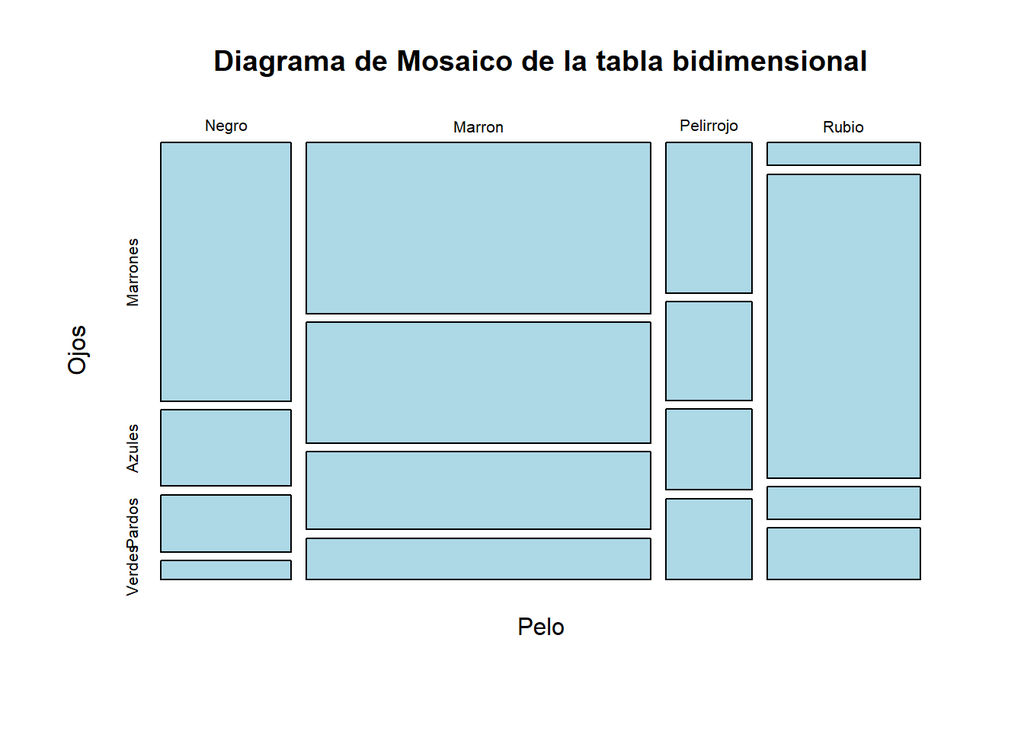

```r
plot(data, color = ("lightblue"), main = "Diagrama de Mosaico de la tabla bidimensional")
```

A continuación, vamos a calcular el **número total de individuos** representados en esta tabla:

```r
#Suma total de todos los individuos del DataFrame
sum (data)
```

```
## [1] 592
```

Las **tablas de frecuencias absolutas y relativas** de cada variable. El color de ojos va en columnas (2º variable) y el color de pelo va en filas (1º variable).

```r
#Frecuencias absolutas para el color de ojos
colSums(data)
```

```
## Marrones   Azules   Pardos   Verdes
##      220      215       93       64
```

```r
#Frecuencias absolutas para el color de pelo
rowSums (data)
```

```
##     Negro    Marron Pelirrojo     Rubio
##       108       286        71       127
```

```r
#Frecuencias relativa para el color de ojos
#prop.table(colSums(data))
#redondeo a tres decimales
round(prop.table(colSums(data)),3)
```

```
## Marrones   Azules   Pardos   Verdes
##    0.372    0.363    0.157    0.108
```

```r
#Frecuencias absolutas para el color de pelo
#prop.table(rowSums(data))
#redondeo a tres decimales
round(prop.table(rowSums(data)),3)
```

```
##     Negro    Marron Pelirrojo     Rubio
##     0.182     0.483     0.120     0.215
```

Representaremos estas últimas en sendos **diagramas de barras**.

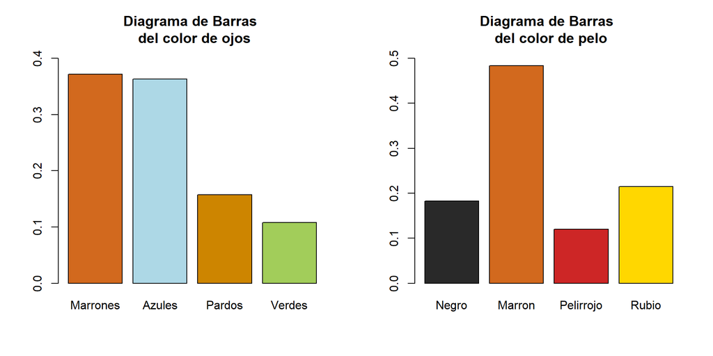

```r
#Establezco que habrá dos gráficos en la misma figura
par(mfrow=c(1,2))

#Represento el barplot del color de ojos (FREC. ABS.)
barplot (prop.table(colSums(data)),
         col = c("chocolate","lightblue","orange3","darkolivegreen3"),
         ylim=c(0,0.4),
         main = "Diagrama de Barras \n del color de ojos")

#Represento el barplot del color de pelo (FREC. ABS.)
barplot (prop.table(rowSums(data)),
         col = c("gray16","chocolate","firebrick3","gold1"),
         ylim=c(0,0.5),
         main = "Diagrama de Barras \n del color de pelo")
```

```r
#cierro la figura
par(mfrow=c(1,1))
```

En el diagrama anterior vemos que el color dominante de cabellos es el castaño, mientras que en el color de ojos el marrón y el azul están prácticamente empatados.

Pasamos ahora a calcular las tablas de **frecuencias relativas** y dibujar los **dos diagramas de barras de las frecuencias relativas marginales**.

```r
#calculo la tabla de FREC. RELAT. de todo el DF
round(prop.table(data),3)
```

```
##            Ojos
## Pelo        Marrones Azules Pardos Verdes
##   Negro        0.115  0.034  0.025  0.008
##   Marron       0.201  0.142  0.091  0.049
##   Pelirrojo    0.044  0.029  0.024  0.024
##   Rubio        0.012  0.159  0.017  0.027
```

```r
#Frencuencia con la que un color de pelo dado, tiene el color de ojos
#calculo la tabla de FREC. RELAT. MARG. para las filas (MARGIN = 1)
round(prop.table(data, margin = 1),3)
```

```
##            Ojos
## Pelo        Marrones Azules Pardos Verdes
##   Negro        0.630  0.185  0.139  0.046
##   Marron       0.416  0.294  0.189  0.101
##   Pelirrojo    0.366  0.239  0.197  0.197
##   Rubio        0.055  0.740  0.079  0.126
```

```r
#Frencuencia con la que un color de ojos dado, tiene el color de pelo
#calculo la tabla de FREC. RELAT. MARG. para las columnas (MARGIN = 2)
round(prop.table(data, margin = 2),3)
```

```
##            Ojos
## Pelo        Marrones Azules Pardos Verdes
##   Negro        0.309  0.093  0.161  0.078
##   Marron       0.541  0.391  0.581  0.453
##   Pelirrojo    0.118  0.079  0.151  0.219
##   Rubio        0.032  0.437  0.108  0.250
```

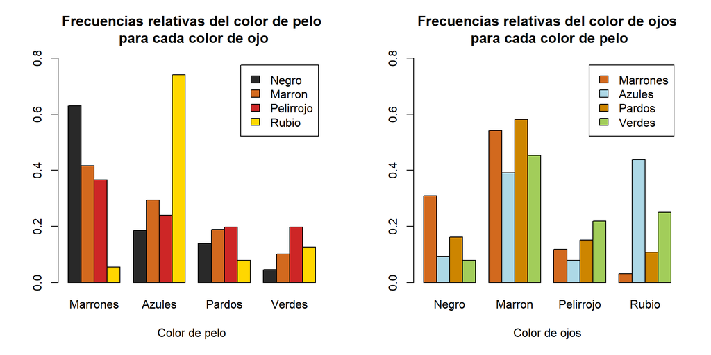

```r
#Establezco que habrá dos gráficos en la misma figura
par(mfrow=c(1,2))

#Represento el barplot (FREC. REL. MARG. FILAS)
barplot (prop.table(data, margin = 1),
         beside =TRUE,
         col = c("gray16","chocolate","firebrick3","gold1"),
         ylim=c(0,0.8),
         main = "Frecuencias relativas del color de pelo\n para cada color de ojo",
         legend.text = TRUE,
         xlab = "Color de pelo")

#Represento el barplot (FREC. REL. MARG. COLUMNAS)
#!CUIDADO! Se representa la transpuesta ya que si no lo pintaría al reves (fila vs columna)
barplot (t(prop.table(data, margin = 2)),
         beside = TRUE,
         col = c("chocolate","lightblue","orange3","darkolivegreen3"),
         ylim=c(0,0.8),
         main = "Frecuencias relativas del color de ojos\n para cada color de pelo",
         legend.text = TRUE,
         xlab = "Color de ojos")
```

```r
#cierro la figura
par(mfrow=c(1,1))
```